# External validation using `pmcalibration`

# Binary outcome

```r
library(pmcalibration)

# simulate some data for vignette
set.seed(2345)
dat <- sim_dat(1000, a1 = -3, a3 = .3)

# show the first 3 columns (col 4 is the true linear predictor/LP)
head(dat[-4])
```

```
#>            x1         x2 y
#> 1 -1.19142464 -0.9245914 0
#> 2  0.54930055 -1.0019698 0
#> 3 -0.06240514  1.5438665 0
#> 4  0.26544150  0.1632147 0
#> 5 -0.23459751 -1.2009388 0
#> 6 -0.99727160 -1.1899600 0
```

We have data with a binary outcome, `y`, and two ‘predictor’ variables, `x1` and `x2`. Suppose we have an existing model for predicting `y` from `x1` and `x2` that is as follows

```
p(y = 1) = plogis( -3 + 1*x1 + 1*x2 )
```

To externally validate this model on this new data we need to calculate the predicted probabilities. We’ll also extract the observed outcomes.

```r
p <- plogis(with(dat, -3 + x1 + x2))
y <- dat$y
```

First we can check ‘calibration-in-the-large’ via the calibration intercept and slope.

```r
logistic_cal(y = y, p = p)
```

```
#> Logistic calibration intercept and slope:
#>
#>                       Estimate Std. Error z value Pr(>|z|) lower upper
#> Calibration Intercept   -0.044       0.12   -0.36   0.7223 -0.29  0.19
#> Calibration Slope        1.336       0.13    2.62   0.0088  1.10  1.60
#>
#> z-value for calibration slope is relative to slope = 1.
#> lower and upper are the bounds of 95% profile confidence intervals.
```

Below we use `pmcalibration` to fit a flexible calibration curve, allowing for a non-linear relationship between predicted and actual probabilities. This assesses ‘moderate calibration’ according to the hierarchy of [Van Calster et al. (2016)](https://pubmed.ncbi.nlm.nih.gov/26772608/).

In the example below, we fit a calibration curve using `mgcv::gam` via a penalized thin plate regression spline (see `?mgcv::tprs`). `pmcalibration` calculates various metrics from the absolute difference between the predicted probability and the actual probability (as estimated by the calibration curve). In this case 95% confidence intervals for these metrics are calculated via simulation based inference.

```r
(cc <- pmcalibration(y = y, p = p,
                     smooth = "gam", bs = "tp",
                     k = 10, transf="logit",
                     ci = "sim", method="REML"))
```

```
#> Calibration metrics based on a calibration curve estimated for a binary outcome via a generalized additive model (see ?mgcv::s) using logit transformed predicted probabilities.
#>
#>      Estimate  lower upper
#> Eavg    0.020 0.0087 0.032
#> E50     0.013 0.0031 0.023
#> E90     0.024 0.0111 0.062
#> Emax    0.211 0.0700 0.305
#> ECI     0.140 0.0263 0.368
#>
#> 95% confidence intervals calculated via simulation based inference with 1000 replicates.
```

The printed metrics can be interpreted as follows:

A quick and simple plot of the calibration curve, and 95% confidence interval, can be obtained via `plot`.

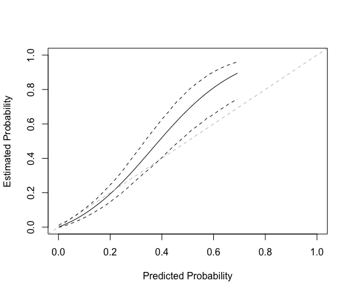

```r
plot(cc)
```

Or one could use `get_cc` to extract data for plotting with method of your choice. The plot below also shows the distribution of predicted probabilities.

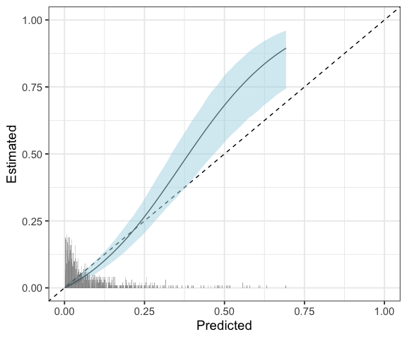

```r
library(ggplot2)

pcc <- get_cc(cc)

ggplot(pcc, aes(x = p, y = p_c, ymin=lower, ymax=upper)) +
  geom_abline(intercept = 0, slope = 1, lty=2) +
  geom_line() +
  geom_ribbon(alpha = 1/2, fill="lightblue") +
  coord_cartesian(xlim=c(0,1), ylim=c(0,1)) +
  labs(x = "Predicted", y = "Estimated") +
  theme_bw(base_size = 14) +
  geom_histogram(data = data.frame(p = p), aes(x=p, y=after_stat(density)*.01),
                 binwidth = .001, inherit.aes = F, alpha=1/2)
```

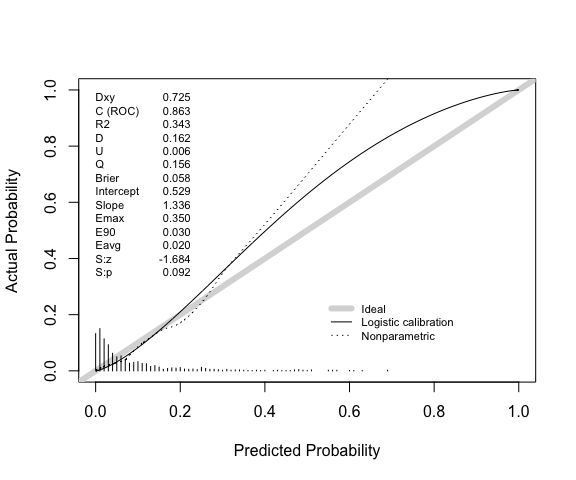

```
#>           Dxy       C (ROC)            R2             D      D:Chi-sq
#>   0.725449678   0.862724839   0.343241418   0.162057146 163.057146265
#>           D:p             U      U:Chi-sq           U:p             Q
#>            NA   0.005910946   7.910945691   0.019149612   0.156146201
#>         Brier     Intercept         Slope          Emax           E90
#>   0.057594793   0.528823286   1.336388397   0.350214394   0.029680412
#>          Eavg           S:z           S:p
#>   0.020095036  -1.684470284   0.092090818
```

```r
library(rms)
val.prob(p = p, y = y)
```

Note also that the calibration intercept reported by `rms::val.prob` comes from the same logistic regression as that used to estimate the calibration slope. In `logistic_cal` the calibration intercept is estimated via a `glm` with logit transformed predicted probabilities included as an offset term (i.e., with slope fixed to 1 - see, e.g., [Van Calster et al., 2016](https://pubmed.ncbi.nlm.nih.gov/26772608/)). The calibration slope is estimated via a separate `glm`.

# Time to event outcome

The code below produces a calibration curve, and associated metrics, for a time-to-event outcome.

```r
library(simsurv)
library(survival)

# simulate some data
n <- 2000
X <- data.frame(id = seq(n), x1 = rnorm(n), x2 = rnorm(n))
X$x3 <- X$x1*X$x2 # interaction

b <- c("x1" = -.2, "x2" = -.2, "x3" = .1)

d <- simsurv(dist = "weibull", lambdas = .01, gammas = 1.5, x = X, betas = b, seed = 246)

mean(d$eventtime)
```

```
#> [1] 19.59251
```

```r
median(d$eventtime)
```

```
#> [1] 16.53999
```

```r
mean(d$status) # no censoring
```

```
#> [1] 1
```

```r
d <- cbind(d, X[,-1])

head(d)
```

```
#>   id eventtime status         x1         x2         x3
#> 1  1   6.59752      1 -1.8030953 -0.9757324  1.7593385
#> 2  2  28.84754      1  0.8369289 -1.6105987 -1.3479566
#> 3  3  14.84345      1 -0.4916106  0.8366313 -0.4112968
#> 4  4  32.89247      1  2.0750555 -0.1059696 -0.2198928
#> 5  5  14.29186      1 -0.4198547 -1.9941478  0.8372523
#> 6  6  11.85858      1 -0.5349368  0.2494071 -0.1334170
```

```r
# split into development and validation
ddev <- d[1:1000, ]
dval <- d[1001:2000, ]

# fit a cox model
cph <- coxph(Surv(eventtime, status) ~ x1 + x2, data = ddev)

# predicted probability of event at time = 15
p = 1 - exp(-predict(cph, type="expected", newdata = data.frame(eventtime=15, status=1, x1=dval$x1, x2=dval$x2)))

y <- with(dval, Surv(eventtime, status))

# calibration curve at time = 15
(cc <- pmcalibration(y = y, p = p, smooth = "rcs", nk = 5, ci = "pw", time = 15))
```

```
#> Calibration metrics based on a calibration curve estimated for a time-to-event outcome (time = 15) via a restricted cubic spline (see ?rms::rcs) using complementary log-log transformed predicted probabilities.
#>
#>      Estimate
#> Eavg    0.035
#> E50     0.029
#> E90     0.070
#> Emax    0.201
#> ECI     0.217
```

```r
# pointwise standard errors for plot but no CI for metrics
# 'boot' CIs are also available for time to event outcomes
```

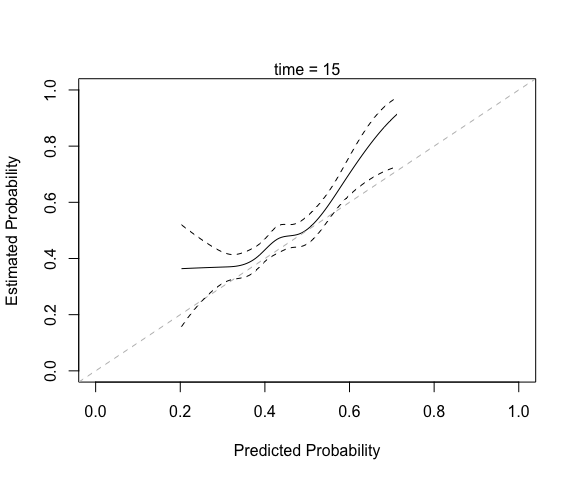

```r
plot(cc)
mtext("time = 15")
```

Compare to `rms::val.surv`, which with the arguments specified below uses `polspline::hare` to fit a calibration curve. Note `val.surv` uses probability of surviving until time = u *not* probability of event occurring by time = u.

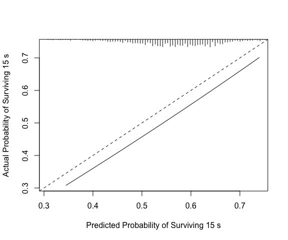

```r
plot(val.surv(S = y, est.surv = 1-p, u=15, fun = function(x) log(-log(x))))
```